# Pelagic productivity and abundance of competitors modulate trophic niche segregation among large sympatric predators

PART 1: Study area and drivers

Version: 02 septiembre, 2025

```r
# load packages
library(readxl)
library(readr)
library(ggplot2)
library(dplyr)
library(mgcv)
library(sf)
library(stars)
library(tidyverse)
library(lattice)
```

# 1 Study area

```r
# load files
samples <- read_excel("SIA/SIA_c3.xlsx") %>%
  filter(Year > 2012 & Year < 2020 & sample == "muscle") %>%
  mutate(Area1 = ifelse(Area == "Baleares/Levante" |Area == "Catalunya" |Area == "Alboran", "WMed", Area)) %>%  unique()
columns <- c("Year","sciname","Species","Area1", "Area2" )
samples[, columns] <- lapply(samples[, columns], as.factor)
```

*Figure 1*. Study area and sampling locations of shortfin mako (IOO), blue shark (PGO), and swordfish (SWO) along the western Mediterranean Sea and the northeastern Atlantic Ocean, from the Gulf of Cádiz to the Canary Islands. Grey lines delineate a spatial grid of 1º × 1º.

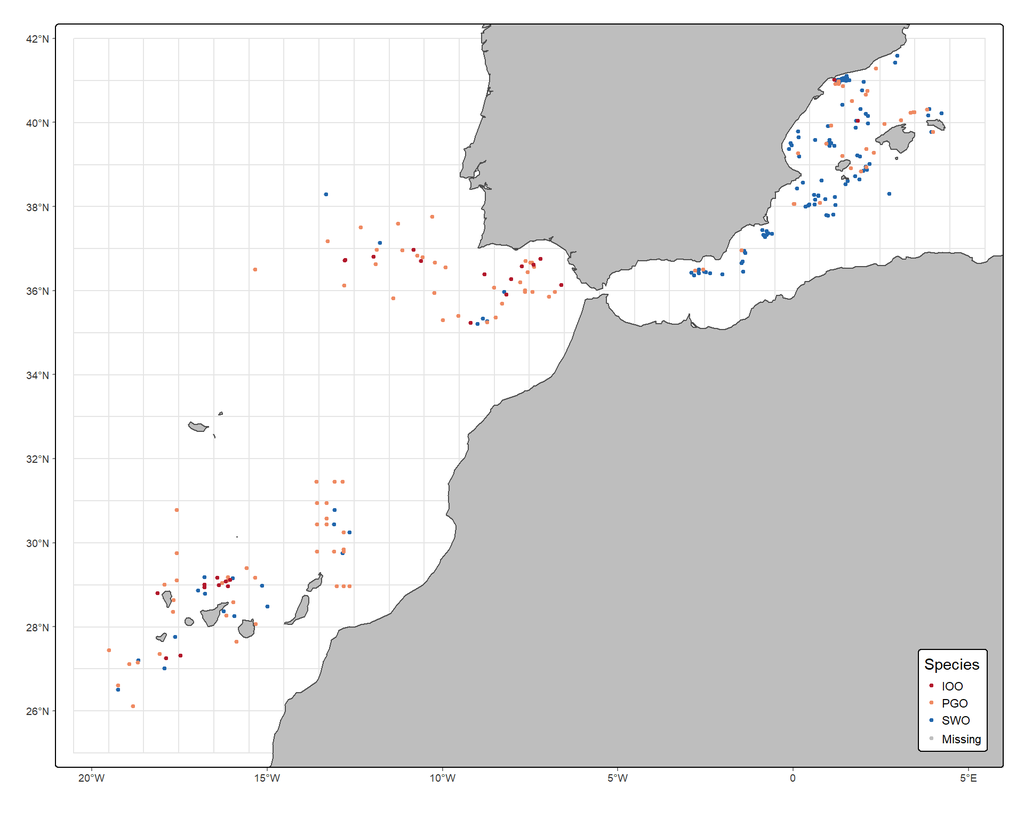

```r
library(tmap)
grid = st_read("spatial/grid.shp") #Load grid
countryshapes = st_read("spatial/sin_frontera.shp") #Load map
samples_sf <- st_as_sf(samples, coords= c("LON","LAT")) #set samples as spatial objects (points)
st_crs(samples_sf) = 4326 #set coordinate reference system CRS

# set map theme
theme_map <- tm_graticules(lines = F) +
  tm_shape(countryshapes) +
  tm_polygons(col = "grey",  border.col = "grey30") +
  tm_layout(bg.color = "white")

pal <- c("#b2182b", "#ef8a62","#2166ac")
palette(pal)

samples_sf <- samples_sf[order(samples_sf$Species, decreasing = TRUE), ]
samples_sf$Species <- factor(samples_sf$Species, levels = c("IOO", "PGO", "SWO"))

# map the samples
tm_shape(grid) + tm_borders(col = "grey90" ) +
   tm_shape(samples_sf, is.master = T) +
    tm_dots(col = "Species", size = 0.25, palette = pal) +
    tm_layout(legend.position = c("right", "bottom")) +
    theme_map
```

# 2 Environmental variables and fishing effort

```r
# Loading spatial / graphical libraries
library(terra)
library(ncdf4)
library(fields)
library(raster)
```

## 2.1 Environmental variables

**Chlorophyll (Chl)** and **Mixed Layer Depth (MLD)** values for the 2015-2019 period were obtained from the EU-Copernicus Marine Environment Monitoring Service (https://marine.copernicus.eu/)

Products:

- *Chlorophyll* GLOBAL_MULTIYEAR_BGC_001_029: cmems_mod_glo_bgc_my_0.25_P1M-M_chl
- *Mixed Layer Depth* GLOBAL_MULTIYEAR_ PHY_001_030: cmems_mod_glo_phy_my_0.083deg_P1M-m_mlotst

```r
#put here the working path where your files have been located
files <- dir("spatial/Env var/", pattern=".nc") #include in the "files" object all the .nc

setwd("spatial/Env var/")

## Chlorophyll
name <-files[1]
aa<-nc_open(name) #open de .nc file.
lat<-ncvar_get(aa,varid="latitude") #latitude
lon<-ncvar_get(aa,varid="longitude") #longitude: -180 to 180
chl_all<-ncvar_get(aa,varid="chl") #chl; 4 dimensions (lon, lat,depth, date)
time<-ncvar_get(aa,varid="time") #"seconds since 1970-01-01 00:00:00"
dates<-as.POSIXct(time, origin = "1970-01-01", tz = "GMT") # we transform number of days (time) into actual dates

# select the first dimension of depth for SSChl
chl <- chl_all[,,1,]

# mean values of date for depth lon and lat
chl_min <- apply(chl,c(1,2),"min")
chl_max <- apply(chl,c(1,2),"max")
chl_mean <- apply(chl,c(1,2),"mean")

# Transform to raster
chl_mean2015_2019 <- raster(chl_mean) # transform the matrix into a raster
chl_mean2015_2019 <- t(flip(chl_mean2015_2019, direction="x")) #to rotate the raster
projection(chl_mean2015_2019) <- "+proj=longlat +ellps=WGS84 +datum=WGS84 +no_defs" #define projection
bb<-extent(min(lon),max(lon),min(lat),max(lat))
chl_mean2015_2019<-setExtent(chl_mean2015_2019,bb,keepres=FALSE, snap=FALSE) # apply the bounding box to the raster
#writeRaster(chl_mean2015_2019, filename="spatial/rasters/chl_mean2015_2019.tif", overwrite=TRUE) #geotif

## MLD
name <-files[4]
aa<-nc_open(name) #open de .nc file.
lat<-ncvar_get(aa,varid="latitude") #latitude
lon<-ncvar_get(aa,varid="longitude") #longitude: -180 to 180
mld<-ncvar_get(aa,varid="mlotst") #density ocean mixed layer thickness; 3 dimensions (lon, lat, date)
time<-ncvar_get(aa,varid="time") #"seconds since 1970-01-01 00:00:00"
dates<-as.POSIXct(time, origin = "1970-01-01", tz = "GMT") # we transform number of days (time) into actual dates

mld_min <- apply(mld,c(1,2),"min")
mld_max <- apply(mld,c(1,2),"max")
mld_mean <- apply(mld,c(1,2),"mean")

# Transform to raster
mld_mean2015_2019 <- raster(mld_mean) # transform the matrix into a raster
mld_mean2015_2019 <- t(flip(mld_mean2015_2019, direction="x")) #to rotate the raster
projection(mld_mean2015_2019) <- "+proj=longlat +ellps=WGS84 +datum=WGS84 +no_defs" #define projection
bb<-extent(min(lon),max(lon),min(lat),max(lat))
mld_mean2015_2019<-setExtent(mld_mean2015_2019,bb,keepres=FALSE, snap=FALSE) # apply the bounding box to the raster
#writeRaster(mld_mean2015_2019, filename="spatial/rasters/mld_mean2015_2019.tif", overwrite=TRUE) #geotif
```

**Pelagic Productivity** was downloaded from https://data.jrc.ec.europa.eu/dataset/a82f0745-6181-4918-9aef-e4dee6149ac6

Druon, Jean-Noel (2021): Ocean Productivity available to Fish (OPFish) - Global Ocean ANNUAL - 2003-2020 (% of daily favorable occurrence, 1/24° by 1/24°) . European Commission, Joint Research Centre (JRC) [Dataset] PID: http://data.europa.eu/89h/a82f0745-6181-4918-9aef-e4dee6149ac6

```r
files <- dir("spatial/Env var/pelagic productivity/", pattern=".nc") #include in the "files" object all the .nc

setwd("spatial/Env var/pelagic productivity/")

opf_ <- array(0,dim=c(4320,8640,length(files)))  # we generate an empty container (array) that will contain annual information on SST for each pixel within the Mediterranean (once masked dimensions will be 67, 190, number of .nc)

for (i in 2:length(files)){
  name <-files[i]
  bb <-nc_open(name) #open de .nc file.
  lat<-ncvar_get(bb,varid="latitude") #latitude
  lon<-ncvar_get(bb,varid="longitude") #longitude: -180 to 180
  opf<-ncvar_get(bb,varid="Feeding_Habitat") #opf; 2 dimensions (lon, lat)

  #add year values to array
  opf_[,,i] <- as.matrix(opf)

    print(i)
}

opf_mean <- apply(opf_,c(1,2),"mean")

# Transform to raster
opf_mean2015_2019 <- raster(opf_mean) # transform the matrix into a raster
projection(opf_mean2015_2019) <- "+proj=longlat +ellps=WGS84 +datum=WGS84 +no_defs" #define projection
bb<-extent(min(lon),max(lon),min(lat),max(lat))
opf_mean2015_2019<-setExtent(opf_mean2015_2019,bb,keepres=FALSE, snap=FALSE) # apply the bounding box to the raster
plot(opf_mean2015_2019)

#writeRaster(opf_mean2015_2019, filename="spatial/rasters/opf_mean2015_2019.tif", overwrite=TRUE) #geotif
```

## 2.2 Fishing effort

Spatially explicit estimates of cumulative fishing effort were obtained from Global Fishing Watch (GFW; Kroodsma et al., 2018; accessed in 2024 from the Google Earth Engine: https://developers.google.com/earth-engine/datasets). We summed daily fishing records from trawlers, purse seiners, gillnets, and longliners to obtain spatially explicit totals covering the 2015–2019 period.

```r
# Load rasters
  ## all fleets
  library(raster)
  library(sp)

  setwd("spatial/FishingEffort")
  wd = "spatial/FishingEffort"
  temp = list.files(pattern="*.tif")
  myfiles = lapply(temp, raster)
  myfiles[[1]]
  plot(myfiles[[20]])

  # Crop rasters
    #extent: xmin = -21.5, xmax=6.5, ymin=24, ymax=44
    crop <- c(-21.495,6.505,24.005,44.005)
    #crop the raster
    rasters_crop <- lapply(myfiles, FUN = crop, y = crop)
    #plot cropped rasters
    plot(rasters_crop[[18]])

  # Add rasters
    s <- raster::stack(rasters_crop)
    raster_sum <- sum(s)
    plot(raster_sum)

  # write raster
#    writeRaster(raster_sum, filename = "spatial/fishingeffort20152019", format="GTiff", overwrite=TRUE)
```

## 2.3 Add drivers to the 1x1 grid

```r
# put here the working path where your files have been located
raster_files <- dir("spatial/rasters", pattern=".tif") #include in the "files" object all the .tif

# create empty list
raster_list <- list()

# Load and process rasters in a loop
for (i in 1:length(raster_files)) {

  file <- raster_files[i]
  raster_path <- paste("spatial/rasters/", file, sep = "") # Adjust the path accordingly
  # Load raster
  raster_data <- raster(raster_path)
  # Assign to a variable (you might want to use a list to store multiple variables)
  assign(gsub(".tif", "", file), raster_data)
  # create list
  raster_list [i] <- raster_data

}

# load grid
grid = st_read("spatial/grid.shp")
grid_drivers = grid
```

```r
for (i in 1:length(raster_list)){
    kk2 <- raster_list[[i]]
  # mean env var values per gridcell
  if (names(kk2) == "fishingeffort20152019"){
  env_var <- as.data.frame(raster::extract(kk2, grid, fun = sum, na.rm = TRUE, sp = TRUE))
  grid_drivers  <- merge(grid_drivers, env_var[,c(1,8)], by = "id")
    print(i)

  } else {
    env_var <- as.data.frame(raster::extract(kk2, grid, fun = mean, na.rm = TRUE, sp = TRUE))
  grid_drivers  <- merge(grid_drivers, env_var[,c(1,8)], by = "id")
    print(i)
    }
}

write.table(st_drop_geometry(grid_drivers), "spatial/grid_env_fe.csv", sep = ";", dec = ".")
st_write(grid_drivers, ".", "grid_env_fe",
      driver = "ESRI Shapefile")
```

## 2.4 Collinearity

```r
library(corrplot)
drivers <- read.csv("spatial/grid_env_fe.csv", sep = ";", dec = ".") %>%
  rename(Chl = chl_mean2015_2019,
         'Fishing effort' = fishingeffort20152019,
         MLD = mld_mean2015_2019,
         OPF= opf_mean2015_2019)

env_cor <- cor(drivers[, c(8:11)], method = "spearman", use = "complete.obs")
round(env_cor, 2)
```

```
#>                  Chl Fishing effort   MLD   OPF
#> Chl             1.00           0.59 -0.76  0.94
#> Fishing effort  0.59           1.00 -0.59  0.59
#> MLD            -0.76          -0.59  1.00 -0.76
#> OPF             0.94           0.59 -0.76  1.00
```

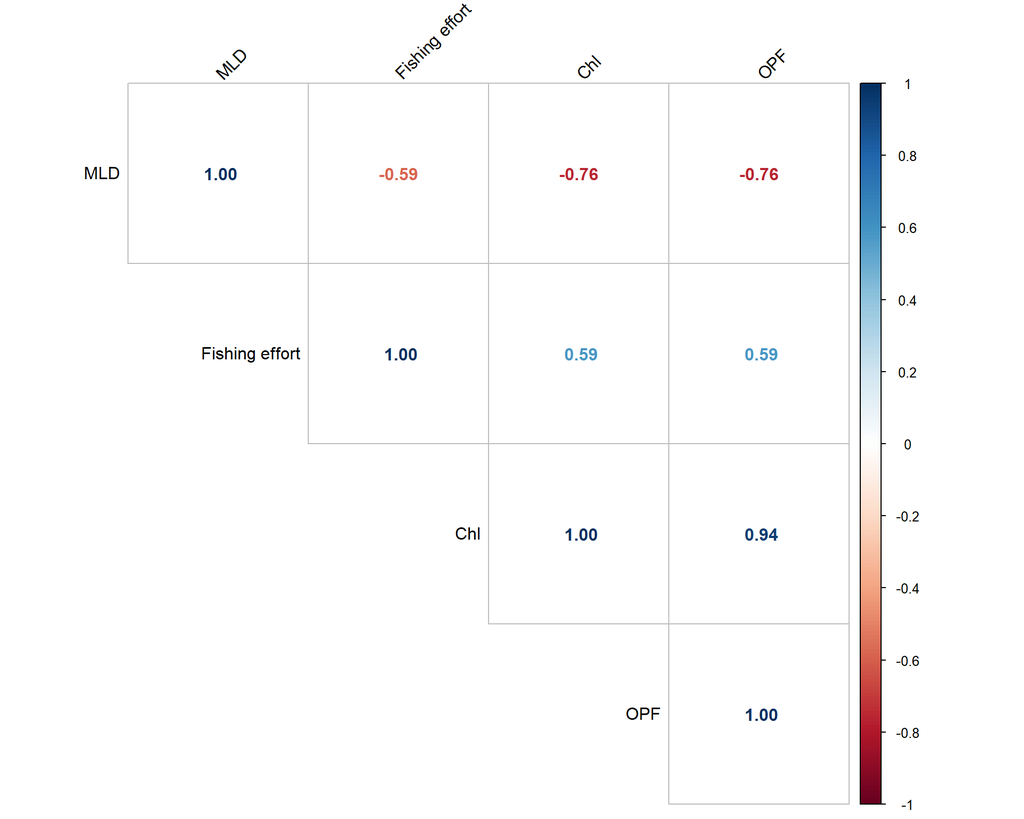

```r
corrplot(env_cor, method = "number",type = "upper", order = "hclust",
         tl.col = "black", tl.srt = 45, number.cex = 1)
```

Delete the variables with correlation higher than 0.8

## 2.5 Description of the study area

Map the variables

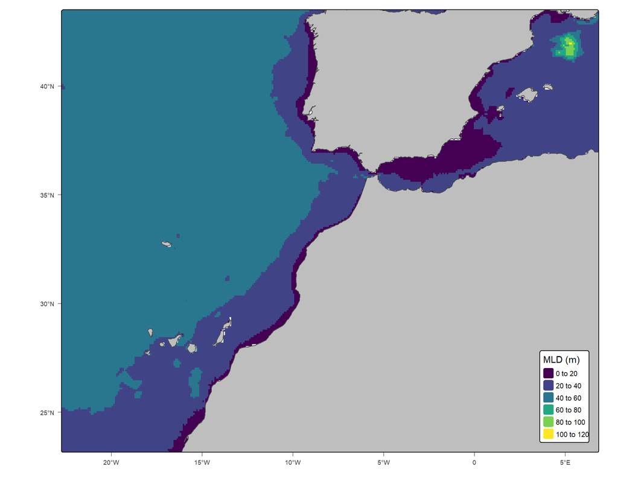

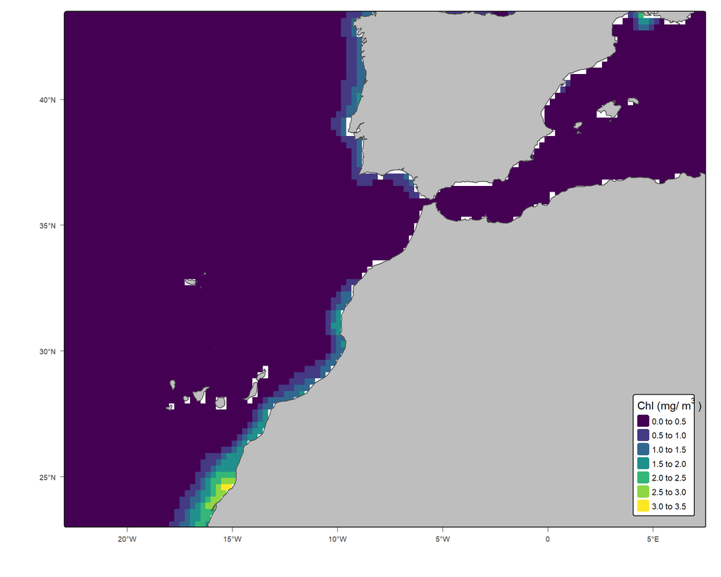

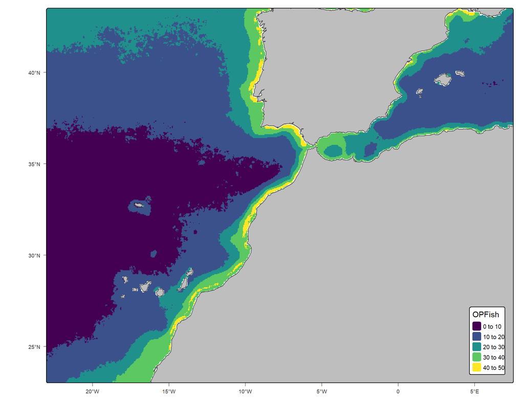

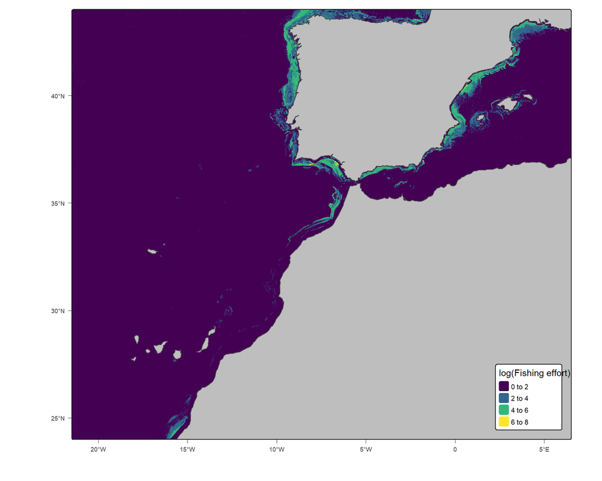

```r
#aes
library(viridis)
bb<-extent(-23, 7.5, 23, 43.5)
opf_mean2015_2019<-crop(opf_mean2015_2019,bb)
logFE = log(fishingeffort20152019+1)

#plot
par(mfrow = c(2, 2))
tm_shape(mld_mean2015_2019) +
  tm_raster(palette = viridis(100), title = "MLD (m)") +
  tm_layout(legend.position = c("right", "bottom"))  +
    theme_map

tm_shape(chl_mean2015_2019) +
  tm_raster(palette = viridis(100), title = expression("Chl (mg/"~m^3~")")) +
  tm_layout(legend.position = c("right", "bottom"))  +
    theme_map

tm_shape(opf_mean2015_2019) +
  tm_raster(palette = viridis(100), title = "OPFish") +
  tm_layout(legend.position = c("right", "bottom"))  +
    theme_map

tm_shape(logFE) +
  tm_raster(palette = viridis(100), title = "log(Fishing effort)") +
  tm_layout(legend.position = c("right", "bottom"))  +
    theme_map
```

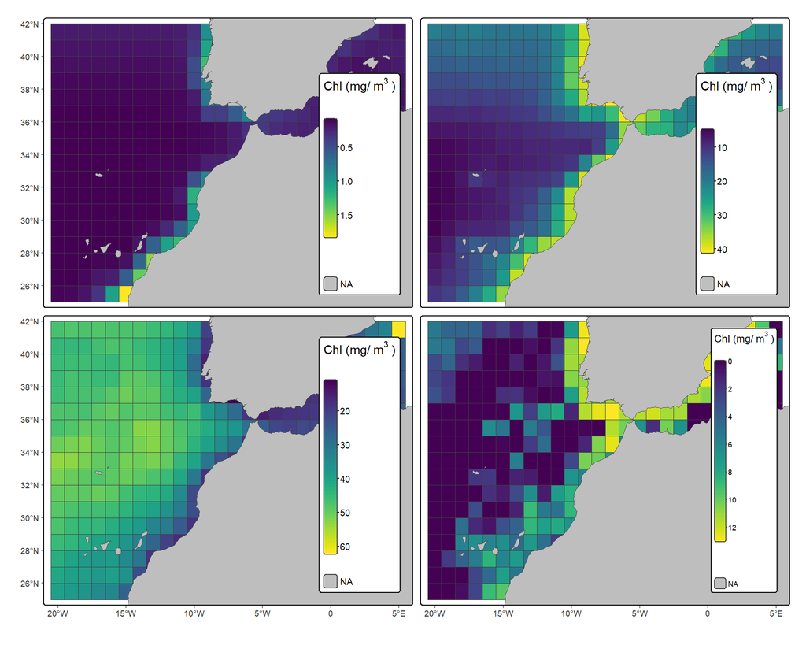

*Figure S1*. Average value per grid cell of the potential environmental drivers obtained from Copernicus and cumulative fishing effort calculated from Global Fishing Watch for the 2015-2019 period. Fishing effort is represented in a logarithmic scale for visualization.

```r
drivers <- st_read("spatial/grid_env_fe.shp")  %>%
  mutate(logFE = log(f201520+1), Chl = c_2015_,  OPF = o_2015_, MLD = m_2015_)
tm_shape(drivers, is.master = T) +
  tm_polygons(col = c("Chl", "OPF", "MLD", "logFE"),
              title = c(expression("Chl (mg/"~m^3~")"), "OPFish", "MLD (m)", expression("log(Fishing effort)(h/"~km^2~")")), style = "cont", textNA = "NA", borders.alpha = 0.5, colorNA = NA, palette = viridis(100)) +
  theme_map + tm_layout(legend.position = c("right", "bottom"), panel.show = FALSE) +
  tm_facets(sync = T, ncol = 2)
```

# 3 Relative abundance of competitors

As a proxy of the relative abundance of the three studied species, a total of 2,534 longline sets from the Spanish longline fleet targeting swordfish and albacore tuna (*Thunnus alalunga*) along the study area between 2015 and 2019 were included in the analysis (IEO-CSIC database ).

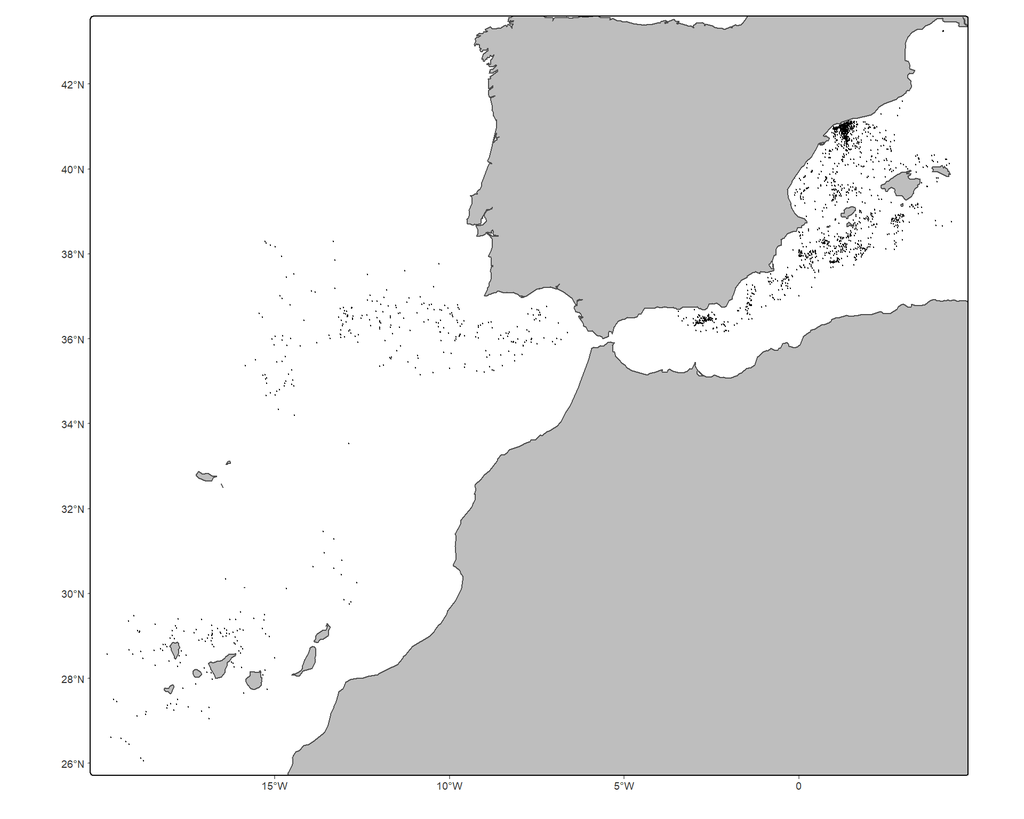

```r
# import data
sets <- read.table("CPUE/lances_capt_grid.csv", sep = ";", dec = ".", header = T)

# map the sampled longline sets and the density of hooks
sets_sf <- st_as_sf(sets, coords= c("VLONINI","VLATINI"))
st_crs(sets_sf) = 4326

sets_sf   %>%
  mutate(Year = as.factor(ANO), longline = as.factor(PALANGRE))  %>%
  filter(ANO < 2020) %>%
  tm_shape(is.master = T) +
    tm_dots(size =  0.05, col= "#21908CFF") + # style = "cont"
    tm_layout(legend.position = c("right", "bottom")) +
    theme_map
```

## 3.1 Standardize the nCPUE

The catch per unit effort (nCPUE) was standardized by applying generalized additive models (GAMs)

- negative binomial error distribution to account for dispersion in the catch data
- number of hooks was included as an offset
- Latitude and longitude were incorporated using a tensor product smooth function to capture spatial variation in catch rates
- longline type was included as a fixed factor
- year and boat were treated as random effects to account for variability in sampling effort and fishing efficiency

Separate models were fitted for each species and basin (Mediterranean and Atlantic), resulting in five models, with no model adjusted for mako sharks in the Mediterranean Sea due to an excess of zero catch observations.

```r
# load
catch <- read.table("CPUE/lances_capt_grid.csv", sep = ";", dec = ".", header = T) %>%
  rename(n_hooks = NUMANZUELOS)

catch[c("year", "month", "palangre", "boat", "gridcell", "FASELUNAR","COESP", "id_lance")] <- lapply(catch[c("ANO", "MES","PALANGRE", "COBARCO", "id", "FASELUNAR", "COESP", "id_lance")], as.factor)

swomed = catch %>% filter(COESP == "SWO" & ANO < 2020 & id != 501)  %>% filter(PALANGRE == 1 | PALANGRE == 3 | PALANGRE == 5)
swoatl = catch %>% filter(COESP == "SWO" & ANO < 2020 & basin == "atl")
pgomed = catch %>% filter(COESP == "BSH" & ANO < 2020 & basin == "med")
pgoatl = catch %>% filter(COESP == "BSH" & ANO < 2020 & basin == "atl")
iooatl = catch %>% filter(COESP == "SMA" & ANO < 2020 & basin == "atl")
```

Explore looking for 0s

```r
# Group by species and basin
catch %>%
  group_by(basin, COESP) %>%
  summarize(
    total_rows = n(),
    zero_catch_rows = sum(n_ind == 0),
    ratio = zero_catch_rows / total_rows
  )
```

```
#> # A tibble: 6 × 5
#> # Groups:   basin [2]
#>   basin COESP total_rows zero_catch_rows   ratio
#>   <chr> <fct>      <int>           <int>   <dbl>
#> 1 atl   BSH          527              81 0.154
#> 2 atl   SMA          527             396 0.751
#> 3 atl   SWO          527               2 0.00380
#> 4 med   BSH         2007            1521 0.758
#> 5 med   SMA         2007            1985 0.989
#> 6 med   SWO         2007             136 0.0678
```

### 3.1.1 Swordfish nCPUE

1. Mediterranean

```r
fit_swo_med <- gam(n_ind ~ te(VLONINI,VLATINI) + palangre +
            s(boat, bs = 're') + s(year, month, bs = 're')+
              offset(log(n_hooks)),
              data = swomed, family = nb())

summary(fit_swo_med)
```

```
#>
#> Family: Negative Binomial(6.065)
#> Link function: log
#>
#> Formula:
#> n_ind ~ te(VLONINI, VLATINI) + palangre + s(boat, bs = "re") +
#>     s(year, month, bs = "re") + offset(log(n_hooks))
#>
#> Parametric coefficients:
#>             Estimate Std. Error z value Pr(>|z|)
#> (Intercept) -5.49369    0.40154 -13.681  < 2e-16 ***
#> palangre3    0.33892    0.09799   3.459 0.000543 ***
#> palangre5    0.71762    0.13376   5.365 8.09e-08 ***
#> ---
#> Signif. codes:  0 '***' 0.001 '**' 0.01 '*' 0.05 '.' 0.1 ' ' 1
#>
#> Approximate significance of smooth terms:
#>                        edf Ref.df  Chi.sq  p-value
#> te(VLONINI,VLATINI)  9.267  11.54   43.38 1.79e-05 ***
#> s(boat)             13.652  14.00  402.43  0.00387 **
#> s(year,month)       30.764  37.00 1523.32 9.45e-05 ***
#> ---
#> Signif. codes:  0 '***' 0.001 '**' 0.01 '*' 0.05 '.' 0.1 ' ' 1
#>
#> R-sq.(adj) =  0.534   Deviance explained = 55.2%
#> -REML = 3459.3  Scale est. = 1         n = 983
```

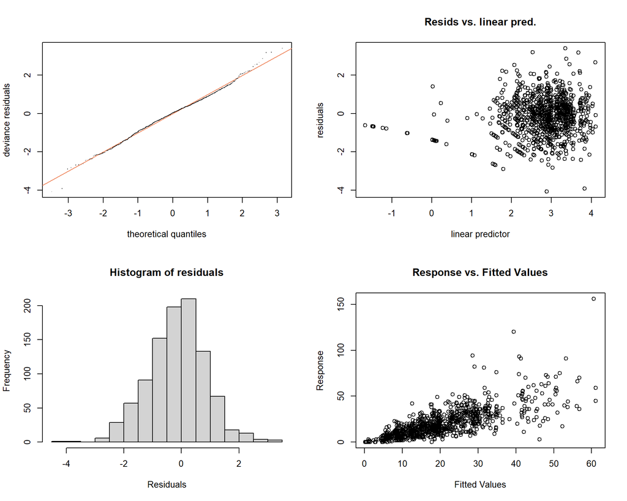

```
#>
#> Method: REML   Optimizer: outer newton
#> full convergence after 4 iterations.
#> Gradient range [-5.607781e-05,0.000305815]
#> (score 3459.311 & scale 1).
#> Hessian positive definite, eigenvalue range [0.7355781,234.8595].
#> Model rank =  92 / 92
#>
#> Basis dimension (k) checking results. Low p-value (k-index<1) may
#> indicate that k is too low, especially if edf is close to k'.
#>
#>                        k'   edf k-index p-value
#> te(VLONINI,VLATINI) 24.00  9.27    0.83  <2e-16 ***
#> s(boat)             15.00 13.65      NA      NA
#> s(year,month)       50.00 30.76      NA      NA
#> ---
#> Signif. codes:  0 '***' 0.001 '**' 0.01 '*' 0.05 '.' 0.1 ' ' 1
```

```r
par(mfrow = c(2, 2))
gam.check(fit_swo_med)
```

2. Atlantic

```r
fit_swo_atl <- gam(n_ind ~ te(VLONINI,VLATINI) +
            s(boat, bs = 're') + s(year, month, bs = 're')+
              offset(log(n_hooks)),
              data = swoatl, family = nb())

summary(fit_swo_atl)
```

```
#>
#> Family: Negative Binomial(6.616)
#> Link function: log
#>
#> Formula:
#> n_ind ~ te(VLONINI, VLATINI) + s(boat, bs = "re") + s(year, month,
#>     bs = "re") + offset(log(n_hooks))
#>
#> Parametric coefficients:
#>             Estimate Std. Error z value Pr(>|z|)
#> (Intercept)  -4.2986     0.1747  -24.61   <2e-16 ***
#> ---
#> Signif. codes:  0 '***' 0.001 '**' 0.01 '*' 0.05 '.' 0.1 ' ' 1
#>
#> Approximate significance of smooth terms:
#>                        edf Ref.df Chi.sq  p-value
#> te(VLONINI,VLATINI)  6.879  8.693  22.67 0.005585 **
#> s(boat)              3.917  6.000 598.55 0.000187 ***
#> s(year,month)       21.994 26.000 815.79  < 2e-16 ***
#> ---
#> Signif. codes:  0 '***' 0.001 '**' 0.01 '*' 0.05 '.' 0.1 ' ' 1
#>
#> R-sq.(adj) =  0.377   Deviance explained = 49.2%
#> -REML = 1199.1  Scale est. = 1         n = 382
```

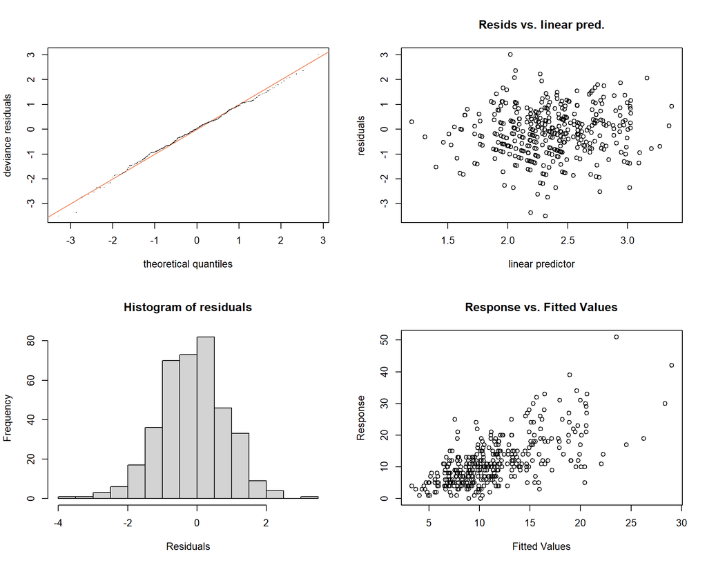

```
#>
#> Method: REML   Optimizer: outer newton
#> full convergence after 4 iterations.
#> Gradient range [-1.60177e-06,1.449301e-06]
#> (score 1199.085 & scale 1).
#> Hessian positive definite, eigenvalue range [0.345123,62.49935].
#> Model rank =  67 / 67
#>
#> Basis dimension (k) checking results. Low p-value (k-index<1) may
#> indicate that k is too low, especially if edf is close to k'.
#>
#>                        k'   edf k-index p-value
#> te(VLONINI,VLATINI) 24.00  6.88    0.83  <2e-16 ***
#> s(boat)              7.00  3.92      NA      NA
#> s(year,month)       35.00 21.99      NA      NA
#> ---
#> Signif. codes:  0 '***' 0.001 '**' 0.01 '*' 0.05 '.' 0.1 ' ' 1
```

```r
par(mfrow = c(2, 2))
gam.check(fit_swo_atl)
```

### 3.1.2 Blue shark nCPUE

1. Mediterranean

```r
fit_pgo_med <- gam(n_ind ~ te(VLONINI,VLATINI) + palangre + # efectos fijos
            s(boat, bs = 're') + s(year, month, bs = 're')+
              offset(log(n_hooks)),
              data = pgomed, family = nb())

summary(fit_pgo_med)
```

```
#>
#> Family: Negative Binomial(1.159)
#> Link function: log
#>
#> Formula:
#> n_ind ~ te(VLONINI, VLATINI) + palangre + s(boat, bs = "re") +
#>     s(year, month, bs = "re") + offset(log(n_hooks))
#>
#> Parametric coefficients:
#>             Estimate Std. Error z value Pr(>|z|)
#> (Intercept) -8.10649    0.28779 -28.168  < 2e-16 ***
#> palangre3   -1.94719    0.29064  -6.700 2.09e-11 ***
#> palangre5   -3.21221    0.70832  -4.535 5.76e-06 ***
#> palangre6   -0.16465    0.66149  -0.249    0.803
#> palangre7   -0.02025    0.66214  -0.031    0.976
#> palangre8    0.07032    0.19511   0.360    0.719
#> palangre9    0.10832    0.26340   0.411    0.681
#> ---
#> Signif. codes:  0 '***' 0.001 '**' 0.01 '*' 0.05 '.' 0.1 ' ' 1
#>
#> Approximate significance of smooth terms:
#>                        edf Ref.df Chi.sq  p-value
#> te(VLONINI,VLATINI) 11.902  13.86 109.14  < 2e-16 ***
#> s(boat)              7.499  15.00  92.94 0.000315 ***
#> s(year,month)       39.840  51.00 492.22  < 2e-16 ***
#> ---
#> Signif. codes:  0 '***' 0.001 '**' 0.01 '*' 0.05 '.' 0.1 ' ' 1
#>
#> R-sq.(adj) =  0.527   Deviance explained = 61.5%
#> -REML = 1310.8  Scale est. = 1         n = 1401
```

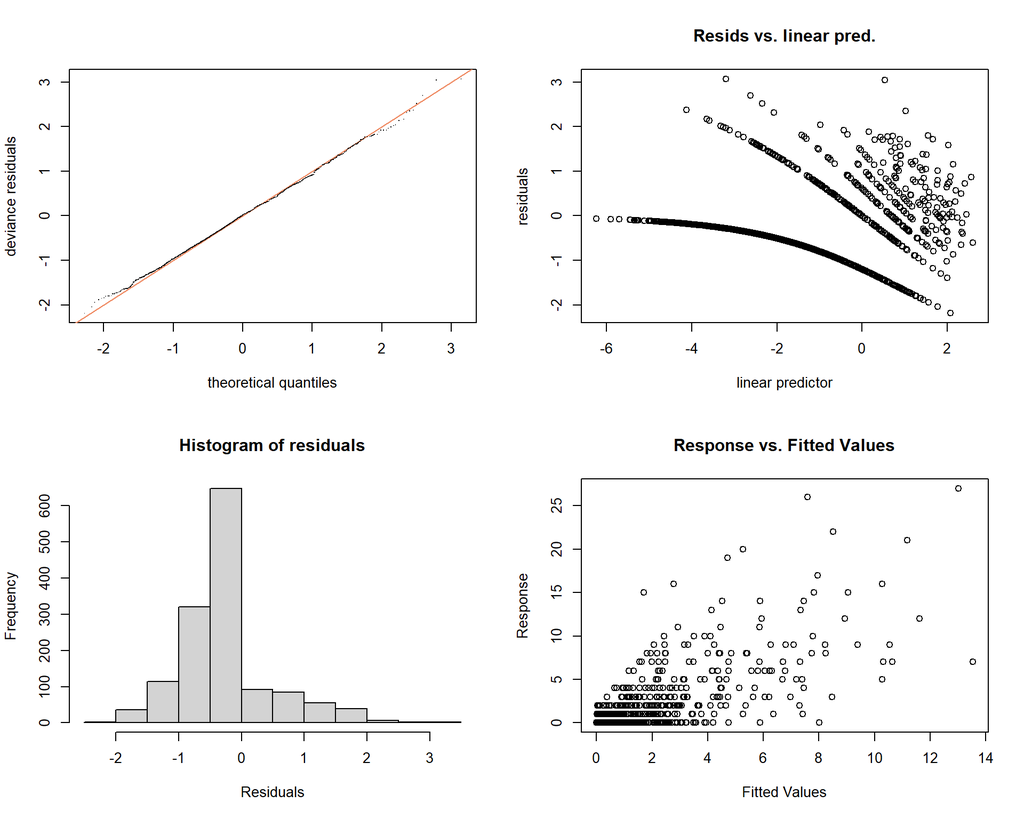

```
#>
#> Method: REML   Optimizer: outer newton
#> full convergence after 4 iterations.
#> Gradient range [-1.475251e-06,7.273674e-06]
#> (score 1310.787 & scale 1).
#> Hessian positive definite, eigenvalue range [0.8052407,61.20184].
#> Model rank =  107 / 107
#>
#> Basis dimension (k) checking results. Low p-value (k-index<1) may
#> indicate that k is too low, especially if edf is close to k'.
#>
#>                       k'  edf k-index p-value
#> te(VLONINI,VLATINI) 24.0 11.9    0.84   0.055 .
#> s(boat)             16.0  7.5      NA      NA
#> s(year,month)       60.0 39.8      NA      NA
#> ---
#> Signif. codes:  0 '***' 0.001 '**' 0.01 '*' 0.05 '.' 0.1 ' ' 1
```

```r
par(mfrow = c(2, 2))
gam.check(fit_pgo_med)
```

2. Atlantic

```r
fit_pgo_atl <- gam(n_ind ~ te(VLONINI,VLATINI) + # efectos fijos
            s(boat, bs = 're') + s(year, month, bs = 're')+
              offset(log(n_hooks)),
              data = pgoatl, family = nb())

summary(fit_pgo_atl)
```

```
#>
#> Family: Negative Binomial(2.231)
#> Link function: log
#>
#> Formula:
#> n_ind ~ te(VLONINI, VLATINI) + s(boat, bs = "re") + s(year, month,
#>     bs = "re") + offset(log(n_hooks))
#>
#> Parametric coefficients:
#>             Estimate Std. Error z value Pr(>|z|)
#> (Intercept)  -5.1879     0.3544  -14.64   <2e-16 ***
#> ---
#> Signif. codes:  0 '***' 0.001 '**' 0.01 '*' 0.05 '.' 0.1 ' ' 1
#>
#> Approximate significance of smooth terms:
#>                        edf Ref.df Chi.sq  p-value
#> te(VLONINI,VLATINI)  8.582  10.31   50.3 1.28e-06 ***
#> s(boat)              4.691   6.00  540.0  0.00178 **
#> s(year,month)       21.309  26.00  234.1  0.00134 **
#> ---
#> Signif. codes:  0 '***' 0.001 '**' 0.01 '*' 0.05 '.' 0.1 ' ' 1
#>
#> R-sq.(adj) =  0.507   Deviance explained = 52.4%
#> -REML =   1138  Scale est. = 1         n = 382
```

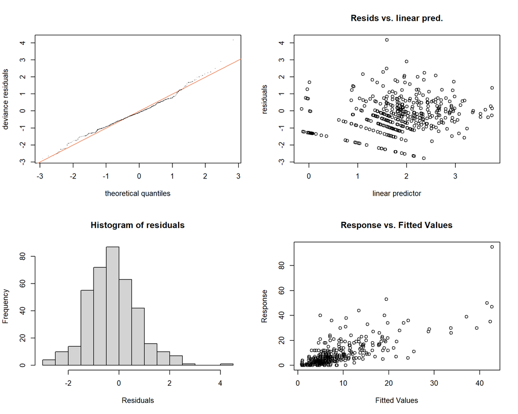

```
#>
#> Method: REML   Optimizer: outer newton
#> full convergence after 4 iterations.
#> Gradient range [-0.0006480417,0.0005318144]
#> (score 1138.032 & scale 1).
#> Hessian positive definite, eigenvalue range [0.3194878,85.07783].
#> Model rank =  67 / 67
#>
#> Basis dimension (k) checking results. Low p-value (k-index<1) may
#> indicate that k is too low, especially if edf is close to k'.
#>
#>                        k'   edf k-index p-value
#> te(VLONINI,VLATINI) 24.00  8.58    0.85   0.005 **
#> s(boat)              7.00  4.69      NA      NA
#> s(year,month)       35.00 21.31      NA      NA
#> ---
#> Signif. codes:  0 '***' 0.001 '**' 0.01 '*' 0.05 '.' 0.1 ' ' 1
```

```r
par(mfrow = c(2, 2))
gam.check(fit_pgo_atl)
```

### 3.1.3 Mako nCPUE

1. Atlantic

```r
fit_ioo_atl <- gam(n_ind ~ te(VLONINI,VLATINI) +
            s(boat, bs = 're') + s(year, month, bs = 're')+
              offset(log(n_hooks)),
              data = iooatl, family = nb())

summary(fit_ioo_atl)
```

```
#>
#> Family: Negative Binomial(1.102)
#> Link function: log
#>
#> Formula:
#> n_ind ~ te(VLONINI, VLATINI) + s(boat, bs = "re") + s(year, month,
#>     bs = "re") + offset(log(n_hooks))
#>
#> Parametric coefficients:
#>             Estimate Std. Error z value Pr(>|z|)
#> (Intercept)  -8.0127     0.2844  -28.17   <2e-16 ***
#> ---
#> Signif. codes:  0 '***' 0.001 '**' 0.01 '*' 0.05 '.' 0.1 ' ' 1
#>
#> Approximate significance of smooth terms:
#>                        edf Ref.df Chi.sq  p-value
#> te(VLONINI,VLATINI)  5.664  6.481  29.40 0.000107 ***
#> s(boat)              1.340  6.000  14.39 0.041785 *
#> s(year,month)       16.313 26.000  74.34 3.27e-05 ***
#> ---
#> Signif. codes:  0 '***' 0.001 '**' 0.01 '*' 0.05 '.' 0.1 ' ' 1
#>
#> R-sq.(adj) =  0.215   Deviance explained = 43.8%
#> -REML =  304.1  Scale est. = 1         n = 382
```

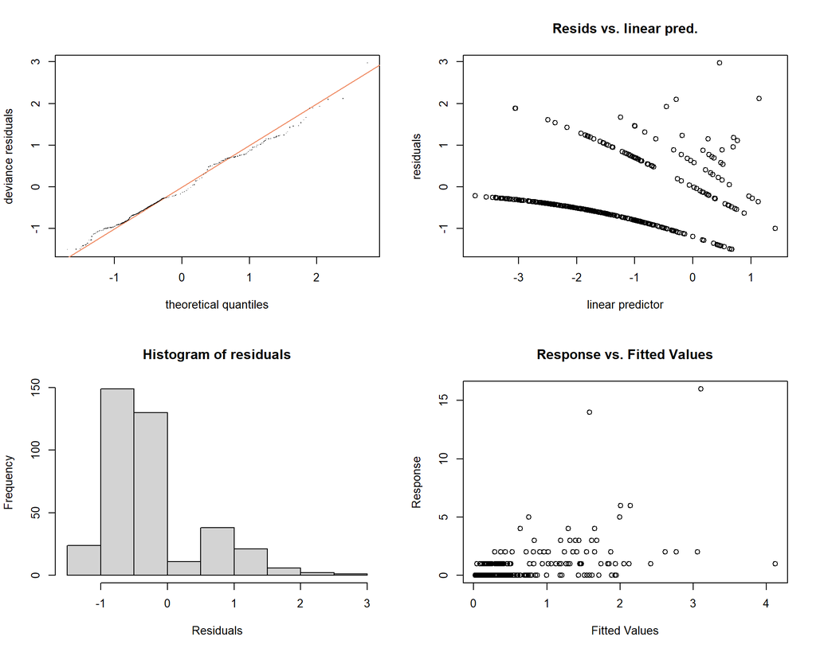

```
#>
#> Method: REML   Optimizer: outer newton
#> full convergence after 9 iterations.
#> Gradient range [-9.296465e-05,2.342974e-05]
#> (score 304.097 & scale 1).
#> Hessian positive definite, eigenvalue range [7.308005e-05,12.43966].
#> Model rank =  67 / 67
#>
#> Basis dimension (k) checking results. Low p-value (k-index<1) may
#> indicate that k is too low, especially if edf is close to k'.
#>
#>                        k'   edf k-index p-value
#> te(VLONINI,VLATINI) 24.00  5.66    0.87    0.58
#> s(boat)              7.00  1.34      NA      NA
#> s(year,month)       35.00 16.31      NA      NA
```

```r
par(mfrow = c(2, 2))
gam.check(fit_ioo_atl)
```

## 3.2 Spatial predictions

Create an empty dataframe for each longline type

```r
p1 <- grid  %>%
  mutate(area = ifelse(id > 310, "med", "atl")) %>%
  filter(id %in% catch$id) %>%
  mutate(VLONINI = centrdX,
         VLATINI = centrdY,
         palangre = as.factor(1),
         n_hooks = 1000,
         boat = as.factor(0),
         year = as.factor(0),
         month = as.factor(0))

for (i in 2:10){
  dataframe <- p1 %>% mutate(palangre = as.factor(i))
  assign(paste0("p",i), dataframe)
}
```

1. Swordfish

```r
# Make predictions without random effects
pred1 <- predict(fit_swo_med, newdata = p1, se.fit = TRUE, type = "response")
pred3 <- predict(fit_swo_med, newdata = p3, se.fit = TRUE, type = "response")
pred5 <- predict(fit_swo_med, newdata = p5, se.fit = TRUE, type = "response")
pred2 <- predict(fit_swo_atl, newdata = p2, se.fit = TRUE, type = "response")

pred <- data.frame(id = p1$id,
                   area = p1$area,
                   p1 = pred1$fit,
                   p3 = pred3$fit,
                   p5 = pred5$fit,
                   sum_atl = pred2$fit)  %>%
        mutate(mean_med = rowMeans(dplyr::select(., starts_with("p"))))  %>%
        summarise(id = id, swo = ifelse(area == "med", mean_med, sum_atl))

grid_ind0 = merge(grid, pred, by  = "id")
```

2. Blue shark

```r
# Make predictions without random effects
pred1 <- predict(fit_pgo_med, newdata = p1, se.fit = TRUE, type = "response")
pred3 <- predict(fit_pgo_med, newdata = p3, se.fit = TRUE, type = "response")
pred5 <- predict(fit_pgo_med, newdata = p5, se.fit = TRUE, type = "response")
pred6 <- predict(fit_pgo_med, newdata = p6, se.fit = TRUE, type = "response")
pred7 <- predict(fit_pgo_med, newdata = p7, se.fit = TRUE, type = "response")
pred8 <- predict(fit_pgo_med, newdata = p8, se.fit = TRUE, type = "response")
pred9 <- predict(fit_pgo_med, newdata = p9, se.fit = TRUE, type = "response")
pred2 <- predict(fit_pgo_atl, newdata = p2, se.fit = TRUE, type = "response")

pred <- data.frame(id = p1$id,
                   area = p1$area,
                   p1 = pred1$fit,
                   p3 = pred3$fit,
                   p5 = pred5$fit,
                   p6 = pred6$fit,
                   p7 = pred7$fit,
                   p8 = pred8$fit,
                   p9 = pred9$fit,
                   sum_atl = pred2$fit)  %>%
        mutate(mean_med = rowMeans(dplyr::select(., starts_with("p"))))  %>%
        summarise(id=id, pgo = ifelse(area == "med", mean_med, sum_atl))

grid_ind1 = merge(grid_ind0, pred, by  = "id")
```

3. Mako shark

```r
# Make predictions without random effects
pred2 <- predict(fit_ioo_atl, newdata = p2, se.fit = TRUE, type = "response")

pred <- data.frame(id = p1$id,
                   area = p1$area,
                   ioo = pred2$fit) %>%
        filter(area == "atl") %>%
        dplyr::select(id, ioo)

grid_ind = merge(grid_ind1, pred, by  = "id", all.x = T)

# cpue <- st_drop_geometry(grid_ind)
# write.table(cpue, "CPUE/grid_cpue.csv", sep= ";", row.names = F)
# st_write(grid_ind, "CPUE/cpue.shp")
```

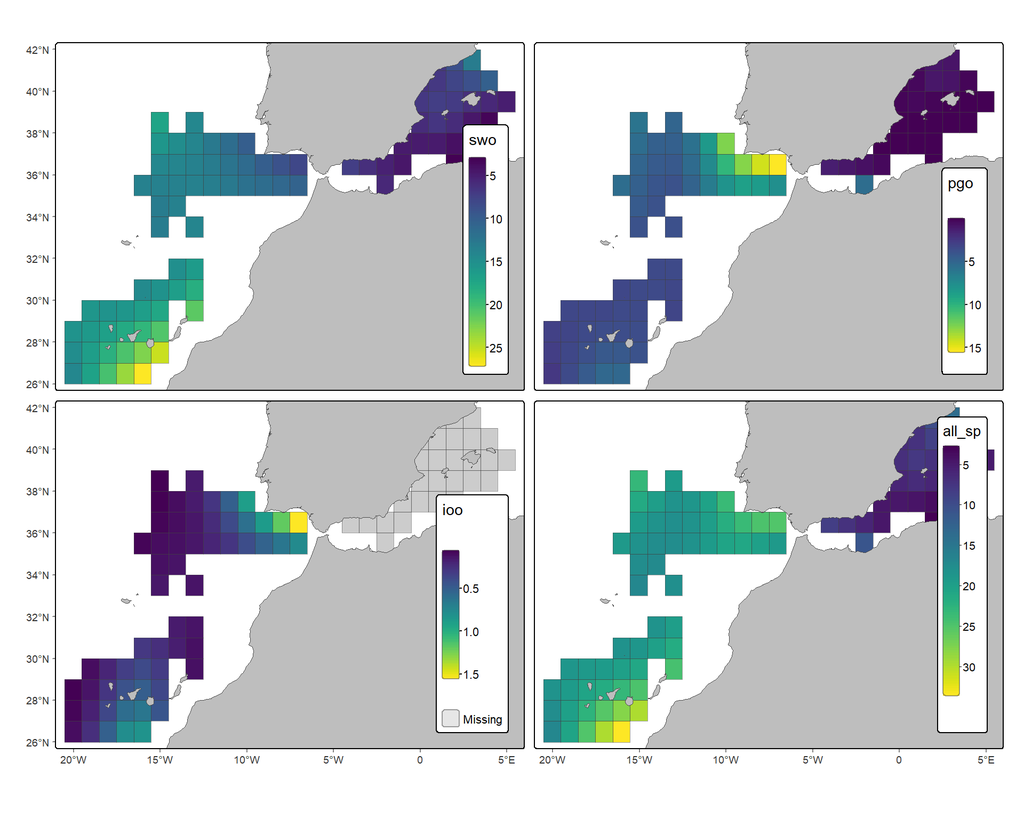

*Figure 2*. Spatial prediction of individuals/1000 hooks (nCPUE) for shortfin mako (IOO), blue shark (PGO), and swordfish (SWO). Data are predicted within a 1º × 1º grid.

```r
grid_ind <- grid_ind %>%
  mutate(swo = as.numeric(swo),
    pgo = as.numeric(pgo),
    ioo = as.numeric(ioo), all_sp = rowSums(across(c(swo, pgo, ioo)), na.rm = TRUE))

tm_shape(grid_ind) +
  tm_polygons(
    fill = c("swo", "pgo", "ioo", "all_sp"),
    col_alpha = 0.5,
    fill.scale = tm_scale_continuous(values = viridis(100), value.na = "grey80")
  ) +
  tm_facets(
    sync = TRUE, ncol = 2
  ) +
  theme_map +
  tm_layout(
    legend.position = c("right", "bottom"),
    panel.show = FALSE
  )
```